# Flow Data

Badhia Yunes Katz

August 2026

## Overview

This vignette summarizes `flow_data`, the packaged flow dataset for the Klamath Basin watershed, along with its companion metadata table `flow_gage`. Gages are grouped by their 8-digit Hydrologic Unit Code (`huc8`) sub-basin - each tab below is one HUC8 sub-basin. For each sub-basin, a date-coverage plot and a summary of the available date range are provided to give an easy visual reference for data availability and to highlight gaps.

`flow_data` covers **January 1996 through December 2025**, with 436,361 records from 69 gages.

Data sources include:

- USGS (via NWIS daily values)
- Water Quality Exchange / Water Quality Portal (WQX)
- U.S. Bureau of Reclamation (via the USBR Hydromet archive)
- Oregon Water Resources Department (OWRD “near real time” hydro stations)

Data collection frequency:

- USGS, USBR Hydromet, and OWRD gages report daily mean flow,
- WQX-sourced tribal sites are periodic grab samples roughly twice a month:

| Source / agency | Gage IDs | Gages | Records | Earliest date | Latest date | Typical frequency |
| --- | --- | --- | --- | --- | --- | --- |
| usgs | 11501000, 11502500, 11504115, 11504260, 11504290, 11507200, 11507500, 11509105, 11509200, 11509250, 11509340, 11509500, 11510700, 11516530, 11517000, 11517500, 11519500, 11520500, 11521500, 11522500, … | 32 | 274245 | 1996-01-01 | 2025-12-31 | daily |
| oregon water resources department | 11491400, 11493500, 11494000, 11494100, 11494200, 11494510, 11494950, 11495600, 11495900, 11497500, 11497550, 11500400, 11500500, 11502550, 11502950, 11502980, 11503000, 11503500, 11504103, 11504109, … | 22 | 119259 | 1996-01-01 | 2025-12-31 | daily |
| bureau of reclamation | usbr-chro, usbr-hrpo, usbr-lrd, usbr-lrs, usbr-lvno, usbr-mhpo, usbr-wilc | 7 | 40375 | 1996-01-01 | 2025-12-31 | daily |
| klamath tribes (tribal) | KLAMATHTRIBES_WQX-SR0040, KLAMATHTRIBES_WQX-SR0050, KLAMATHTRIBES_WQX-SR0060, KLAMATHTRIBES_WQX-SR0070, KLAMATHTRIBES_WQX-SR0080, KLAMATHTRIBES_WQX-SR0090, KLAMATHTRIBES_WQX-SR0140, KLAMATHTRIBES_WQX-… | 8 | 2482 | 2001-03-07 | 2016-12-29 | biweekly (roughly twice a month) |

`flow_data` columns:

- `location`: stream/waterbody associated with the gage
- `gage_name`: name of the gaging station
- `gage_id`: unique identifier for the gage
- `variable_name`: variable measured (“flow”)
- `value`: observed flow value (numeric)
- `unit`: units of measurement (cfs)
- `statistic`: summary statistic type (“mean”)
- `date`: date of the observation

`flow_gage` columns:

- `location`, `gage_name`, `gage_id`: same as above
- `agency`: agency responsible for operating or maintaining the gage
- `latitude`, `longitude`: gage location
- `river_mile`: closest river mile relative to river mouth or a reference point
- `huc8`: 8-digit Hydrologic Unit Code identifying the sub-basin where the gage is located

## Map showing all flow gages

[interactive chart not shown]

## Flow summary by sub-basin

### Williamson (HUC8 18010201)

#### Gages

| location | gage_name | gage_id | agency | river_mile |
| --- | --- | --- | --- | --- |
| williamson river | williamson river blw sprague river nr chiloquin,or | 11502500 | usgs | 8 |
| williamson river | williamson r bl sheep cr nr lenz, or | 11491400 | oregon water resources department | 72 |
| williamson river | williamson r nr klamath agency, or | 11493500 | oregon water resources department | 25 |
| williamson river | williamson r ab spring cr nr klamath agency, or | 11494000 | oregon water resources department | 18 |
| larkin creek | larkin cr nr chiloquin, or | 11494100 | oregon water resources department | NA |
| spring creek | spring cr nr chiloquin, or | 11494200 | oregon water resources department | NA |
| williamson river | williamson r ab sprague r nr chiloquin, or | 11494510 | oregon water resources department | 10 |
| williamson river | williamson r at modoc pt rd, nr chiloquin, or | 11502550 | oregon water resources department | 3 |

#### Date coverage

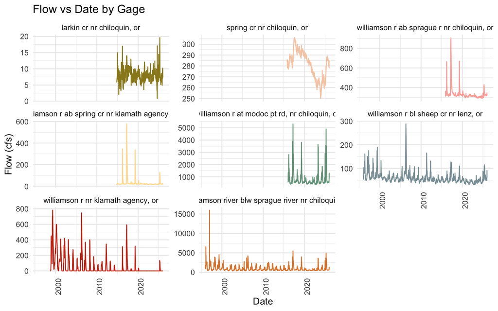

#### Date range summary

| gage_name | gage_id | min_date | max_date | record_count |
| --- | --- | --- | --- | --- |
| larkin cr nr chiloquin, or | 11494100 | 2014-10-28 | 2025-12-31 | 4035 |
| spring cr nr chiloquin, or | 11494200 | 2015-10-30 | 2025-12-31 | 3716 |
| williamson r ab sprague r nr chiloquin, or | 11494510 | 2015-12-01 | 2025-12-31 | 3684 |
| williamson r ab spring cr nr klamath agency, or | 11494000 | 2014-10-01 | 2025-12-31 | 4110 |
| williamson r at modoc pt rd, nr chiloquin, or | 11502550 | 2016-01-16 | 2025-12-31 | 3638 |
| williamson r bl sheep cr nr lenz, or | 11491400 | 1996-01-01 | 2025-12-31 | 10630 |
| williamson r nr klamath agency, or | 11493500 | 1998-10-01 | 2025-12-31 | 9936 |
| williamson river blw sprague river nr chiloquin,or | 11502500 | 1996-01-01 | 2025-12-31 | 10958 |

### Sprague (HUC8 18010202)

#### Gages

| location | gage_name | gage_id | agency | river_mile |
| --- | --- | --- | --- | --- |
| north fork sprague river | north fork sprague river at fs 3411 road | KLAMATHTRIBES_WQX-SR0040 | klamath tribes (tribal) | NA |
| south fork sprague river | south fork sprague river at picnic area | KLAMATHTRIBES_WQX-SR0050 | klamath tribes (tribal) | NA |
| sycan river | sycan river at drews road | KLAMATHTRIBES_WQX-SR0070 | klamath tribes (tribal) | NA |
| sprague river | sprague river at lone pine | KLAMATHTRIBES_WQX-SR0080 | klamath tribes (tribal) | 34 |
| sprague river | sprague river at chiloquin ridge road | KLAMATHTRIBES_WQX-SR0090 | klamath tribes (tribal) | 6 |
| sprague river | sprague river at godowa road | KLAMATHTRIBES_WQX-SR0060 | klamath tribes (tribal) | 73 |
| south fork sprague river | south fork sprague river at ivory pine road | KLAMATHTRIBES_WQX-SR0150 | klamath tribes (tribal) | NA |
| north fork sprague river | north fork sprague river at ivory pine road | KLAMATHTRIBES_WQX-SR0140 | klamath tribes (tribal) | NA |
| sycan river | sycan river | NARS_WQX-WORP99-0514 | epa national aquatic resources survey (nars) | NA |
| fishhole creek | fishhole creek | NARS_WQX-WORP99-0888 | epa national aquatic resources survey (nars) | NA |
| sprague river | sprague river near chiloquin, or | 11501000 | usgs | 6 |
| sf sprague river | sf sprague river nr bly, or | 11495600 | oregon water resources department | NA |
| nf sprague river | n fk sprague r ab sric cn nr bly, or | 11495900 | oregon water resources department | NA |
| south fork sprague river | s fk sprague r at sprague r park nr bly, or | 11494950 | oregon water resources department | NA |
| sprague river | sprague r nr beatty, or | 11497500 | oregon water resources department | 76 |
| sprague river | sprague r bl brown cr nr beatty, or | 11497550 | oregon water resources department | 73 |
| trout creek | trout cr nr lone pine | 11500400 | oregon water resources department | NA |
| sprague river | sprague r at lone pine, or | 11500500 | oregon water resources department | 34 |

#### Date coverage

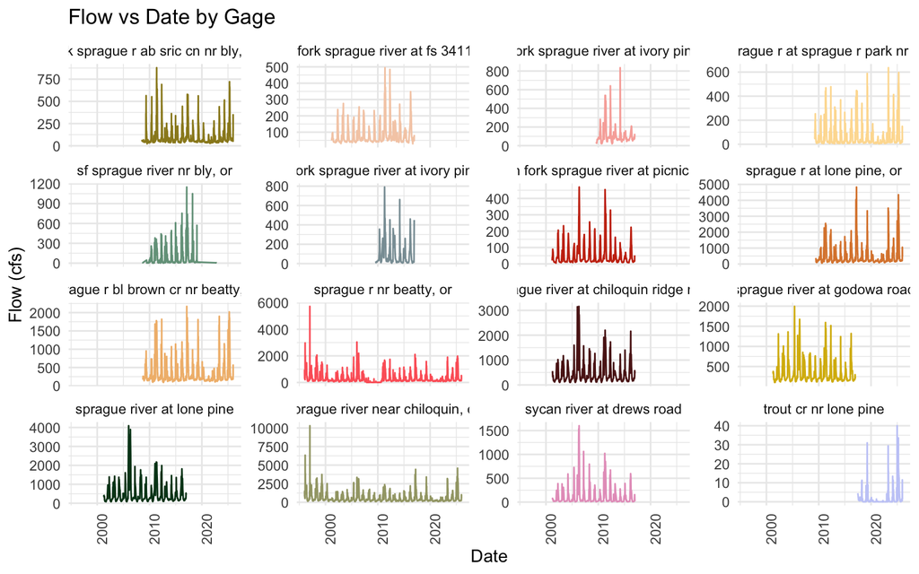

#### Date range summary

| gage_name | gage_id | min_date | max_date | record_count |
| --- | --- | --- | --- | --- |
| n fk sprague r ab sric cn nr bly, or | 11495900 | 2008-07-22 | 2025-12-31 | 6372 |
| north fork sprague river at fs 3411 road | KLAMATHTRIBES_WQX-SR0040 | 2001-03-07 | 2016-12-27 | 347 |
| north fork sprague river at ivory pine road | KLAMATHTRIBES_WQX-SR0140 | 2009-08-12 | 2016-12-27 | 155 |
| s fk sprague r at sprague r park nr bly, or | 11494950 | 2009-04-02 | 2025-12-31 | 6118 |
| sf sprague river nr bly, or | 11495600 | 2008-08-07 | 2022-10-24 | 3668 |
| south fork sprague river at ivory pine road | KLAMATHTRIBES_WQX-SR0150 | 2009-08-11 | 2016-12-16 | 148 |
| south fork sprague river at picnic area | KLAMATHTRIBES_WQX-SR0050 | 2001-03-07 | 2016-12-16 | 326 |
| sprague r at lone pine, or | 11500500 | 2009-06-18 | 2025-12-31 | 6041 |
| sprague r bl brown cr nr beatty, or | 11497550 | 2008-10-01 | 2025-12-31 | 6301 |
| sprague r nr beatty, or | 11497500 | 1996-01-01 | 2025-12-31 | 10958 |
| sprague river at chiloquin ridge road | KLAMATHTRIBES_WQX-SR0090 | 2001-04-04 | 2016-12-29 | 393 |
| sprague river at godowa road | KLAMATHTRIBES_WQX-SR0060 | 2001-03-21 | 2016-12-28 | 382 |
| sprague river at lone pine | KLAMATHTRIBES_WQX-SR0080 | 2001-03-22 | 2016-12-29 | 363 |
| sprague river near chiloquin, or | 11501000 | 1996-01-01 | 2025-12-31 | 10958 |
| sycan river at drews road | KLAMATHTRIBES_WQX-SR0070 | 2001-03-21 | 2016-12-28 | 368 |
| trout cr nr lone pine | 11500400 | 2017-06-23 | 2025-12-31 | 3025 |

### Upper Klamath Lake (HUC8 18010203)

#### Gages

| location | gage_name | gage_id | agency | river_mile |
| --- | --- | --- | --- | --- |
| fourmile canal | fourmile canal near klamath agency, or | 11504260 | usgs | NA |
| sevenmile canal | sevenmile cnl at dike rd br, nr klamath agency, or | 11504290 | usgs | NA |
| wood river | wood river near klamath agency, or | 11504115 | usgs | 0 |
| a canal | a canal at klamath falls, or | 11507200 | usgs | NA |
| cherry creek | cherry creek - flow (cfs) | usbr-chro | bureau of reclamation | NA |
| sun creek | sun cr at ranger sta nr fort klamath, or | 11502950 | oregon water resources department | NA |
| wood river | wood r bl sun cr nr fort klamath, or | 11502980 | oregon water resources department | 19 |
| annie spring | annie spring nr crater lake, or | 11503000 | oregon water resources department | NA |
| annie creek | annie cr nr ft klamath | 11503500 | oregon water resources department | NA |
| wood river | wood r ab crooked cr, nr klamath agency, or | 11504103 | oregon water resources department | 1 |
| crooked creek | crooked cr nr klamath agency, or | 11504109 | oregon water resources department | NA |
| sevenmile creek | sevenmile cr bl dry cr nr fort klamath | 11504120 | oregon water resources department | NA |

#### Date coverage

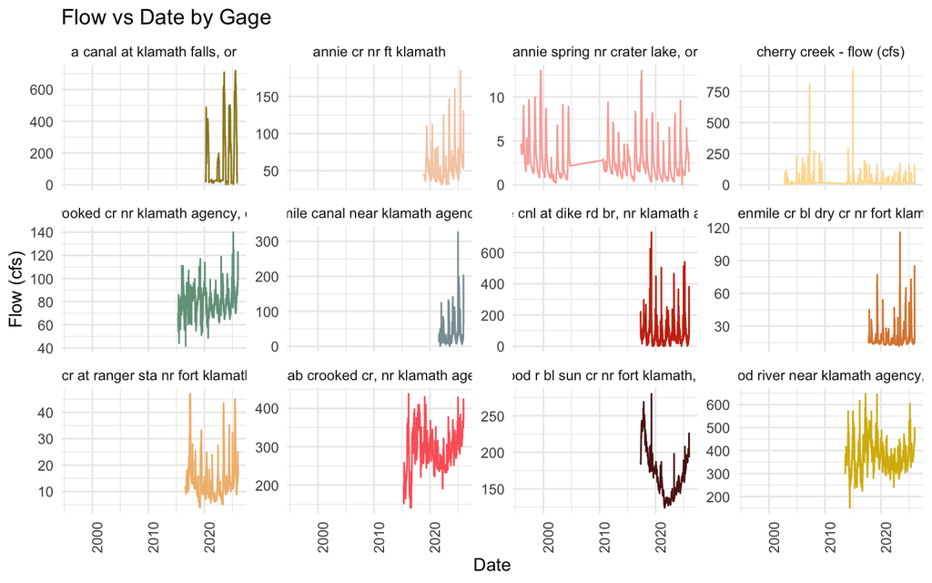

#### Date range summary

| gage_name | gage_id | min_date | max_date | record_count |
| --- | --- | --- | --- | --- |
| a canal at klamath falls, or | 11507200 | 2020-03-24 | 2025-11-06 | 1323 |
| annie cr nr ft klamath | 11503500 | 2018-10-23 | 2025-12-31 | 2358 |
| annie spring nr crater lake, or | 11503000 | 1996-01-01 | 2025-12-31 | 8793 |
| cherry creek - flow (cfs) | usbr-chro | 2002-10-16 | 2025-12-31 | 6166 |
| crooked cr nr klamath agency, or | 11504109 | 2015-04-22 | 2025-12-31 | 3907 |
| fourmile canal near klamath agency, or | 11504260 | 2021-08-05 | 2025-12-31 | 1599 |
| sevenmile cnl at dike rd br, nr klamath agency, or | 11504290 | 2017-05-04 | 2025-12-31 | 3064 |
| sevenmile cr bl dry cr nr fort klamath | 11504120 | 2017-10-01 | 2025-12-31 | 3014 |
| sun cr at ranger sta nr fort klamath, or | 11502950 | 2016-08-01 | 2025-12-31 | 3440 |
| wood r ab crooked cr, nr klamath agency, or | 11504103 | 2015-04-22 | 2025-12-31 | 3906 |
| wood r bl sun cr nr fort klamath, or | 11502980 | 2017-05-09 | 2025-12-31 | 3159 |
| wood river near klamath agency, or | 11504115 | 2013-08-01 | 2025-12-31 | 4535 |

### Lost (HUC8 18010204)

#### Gages

| location | gage_name | gage_id | agency | river_mile |
| --- | --- | --- | --- | --- |
| link river | link river at klamath falls, or | 11507500 | usgs | 0 |
| klamath straits drain | klamath straits drain near worden, or | 11509340 | usgs | NA |
| ady canal | ady canal above lower klamath nwr, near worden, or | 11509250 | usgs | NA |
| north canal | north canal at highway 97, near midland, or | 11509105 | usgs | NA |
| ady canal | ady canal at highway 97, near worden, or | 11509200 | usgs | NA |
| willow creek | willow creek - flow (cfs) | usbr-wilc | bureau of reclamation | NA |
| langell valley north canal | langell valley north canal - flow (cfs) | usbr-lvno | bureau of reclamation | NA |
| miller hill pump plant | miller hill pump plant - flow (cfs) | usbr-mhpo | bureau of reclamation | NA |
| lost river diversion | lost river diversion - flow (cfs) | usbr-lrd | bureau of reclamation | NA |
| lost river at harpold dam | lost river at harpold dam - flow (cfs) | usbr-hrpo | bureau of reclamation | NA |
| clear lake east lobe / lost river | clear lake east lobe / lost river - flow (cfs) | usbr-lrs | bureau of reclamation | NA |

#### Date coverage

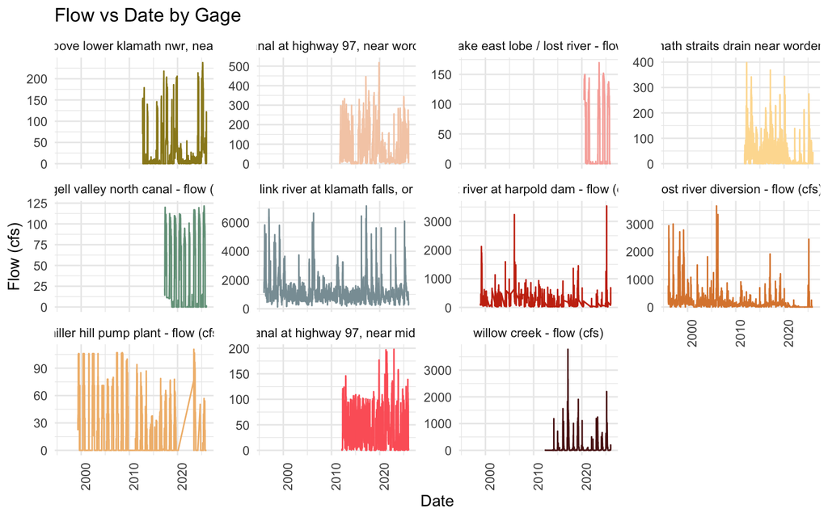

#### Date range summary

| gage_name | gage_id | min_date | max_date | record_count |
| --- | --- | --- | --- | --- |
| ady canal above lower klamath nwr, near worden, or | 11509250 | 2012-09-30 | 2025-12-31 | 3988 |
| ady canal at highway 97, near worden, or | 11509200 | 2011-10-01 | 2025-12-31 | 5063 |
| clear lake east lobe / lost river - flow (cfs) | usbr-lrs | 2020-06-09 | 2025-12-31 | 2027 |
| klamath straits drain near worden, or | 11509340 | 2011-10-31 | 2025-12-31 | 3907 |
| langell valley north canal - flow (cfs) | usbr-lvno | 2017-05-04 | 2025-12-31 | 2930 |
| link river at klamath falls, or | 11507500 | 1996-01-01 | 2025-12-31 | 10958 |
| lost river at harpold dam - flow (cfs) | usbr-hrpo | 1998-12-17 | 2025-12-31 | 5840 |
| lost river diversion - flow (cfs) | usbr-lrd | 1996-01-01 | 2025-12-31 | 10893 |
| miller hill pump plant - flow (cfs) | usbr-mhpo | 1999-04-30 | 2025-12-31 | 8121 |
| north canal at highway 97, near midland, or | 11509105 | 2012-02-29 | 2025-12-31 | 4662 |
| willow creek - flow (cfs) | usbr-wilc | 2012-05-24 | 2025-12-31 | 4398 |

### Butte (HUC8 18010205)

#### Gages

| location | gage_name | gage_id | agency | river_mile |
| --- | --- | --- | --- | --- |
| butte creek | butte creek | NARS_WQX-WCAP99-0756 | epa national aquatic resources survey (nars) | NA |

#### Date coverage

No flow records available for this sub-basin’s gage(s).

#### Date range summary

No flow records available for this sub-basin’s gage(s).

### Upper Klamath (HUC8 18010206)

#### Gages

| location | gage_name | gage_id | agency | river_mile |
| --- | --- | --- | --- | --- |
| howard prairie canal | howard prairie canal at headworks | 1119USBR-ROG110 | bureau of reclamation | NA |
| hyatt prairie | hyatt prairie dam release at outlet works | 1119USBR-ROG124 | bureau of reclamation | NA |
| howard prairie canal | howard prairie canal at headworks | 1119USBR_WQX-ROG110 | bureau of reclamation | NA |
| hyatt prairie | hyattprairiedamreleaseatoutletworks | 1119USBR_WQX-ROG124 | bureau of reclamation | NA |
| shovel creek | shovel creek | NARS_WQX-WCAP99-0833 | epa national aquatic resources survey (nars) | 11 |
| seiad creek | seiad creek | NARS_WQX-WCAP99-0857 | epa national aquatic resources survey (nars) | NA |
| grouse creek | grouse creek | NARS_WQX-WCAP99-0845 | epa national aquatic resources survey (nars) | NA |
| little humbug creek | little humbug creek | NARS_WQX-WCAP99-1064 | epa national aquatic resources survey (nars) | NA |
| klamath river | klamath river at keno, or | 11509500 | usgs | 235 |
| klamath river | klamath river blw john c.boyle pwrplnt, nr keno,or | 11510700 | usgs | 222 |
| klamath river | klamath r bl iron gate dam ca | 11516530 | usgs | 192 |
| klamath river | klamath r nr seiad valley ca | 11520500 | usgs | 130 |
| spencer creek | spencer cr nr keno, or | 11510000 | oregon water resources department | 1 |

#### Date coverage

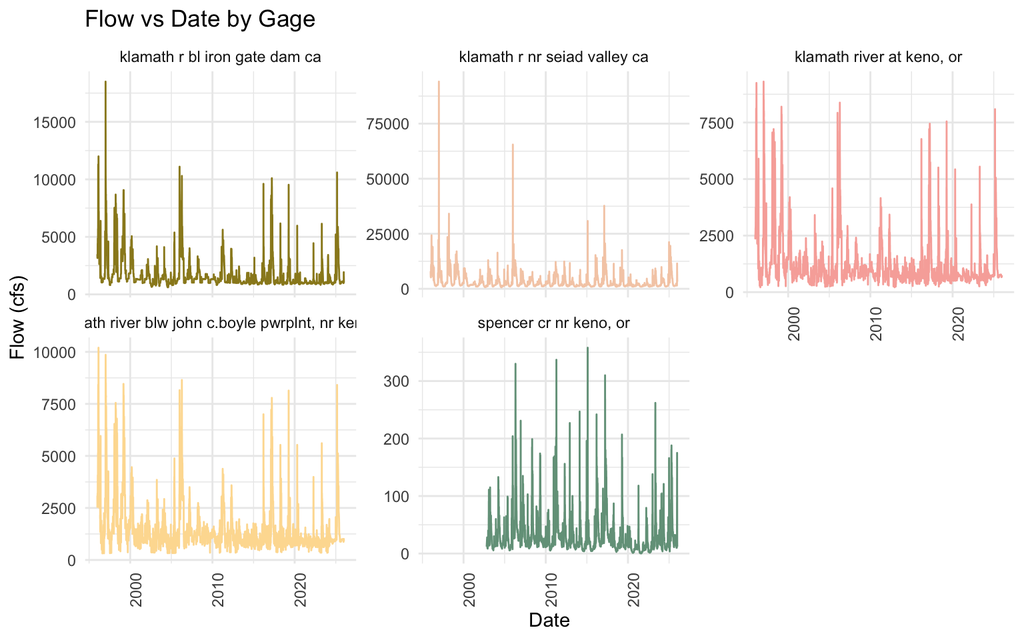

#### Date range summary

| gage_name | gage_id | min_date | max_date | record_count |
| --- | --- | --- | --- | --- |
| klamath r bl iron gate dam ca | 11516530 | 1996-01-01 | 2025-12-31 | 10958 |
| klamath r nr seiad valley ca | 11520500 | 1996-01-01 | 2025-12-31 | 10958 |
| klamath river at keno, or | 11509500 | 1996-01-01 | 2025-12-31 | 10958 |
| klamath river blw john c.boyle pwrplnt, nr keno,or | 11510700 | 1996-01-01 | 2025-12-31 | 10958 |
| spencer cr nr keno, or | 11510000 | 2002-10-24 | 2025-12-31 | 8450 |

### Shasta (HUC8 18010207)

#### Gages

| location | gage_name | gage_id | agency | river_mile |
| --- | --- | --- | --- | --- |
| eddy creek | eddy creek | NARS_WQX-WCAP99-0592 | epa national aquatic resources survey (nars) | NA |
| yreka creek | yreka creek | NARS_WQX-WCAP99-1000 | epa national aquatic resources survey (nars) | NA |
| shasta river | shasta r nr montague ca | 11517000 | usgs | 16 |
| shasta river | shasta r nr yreka ca | 11517500 | usgs | 1 |

#### Date coverage

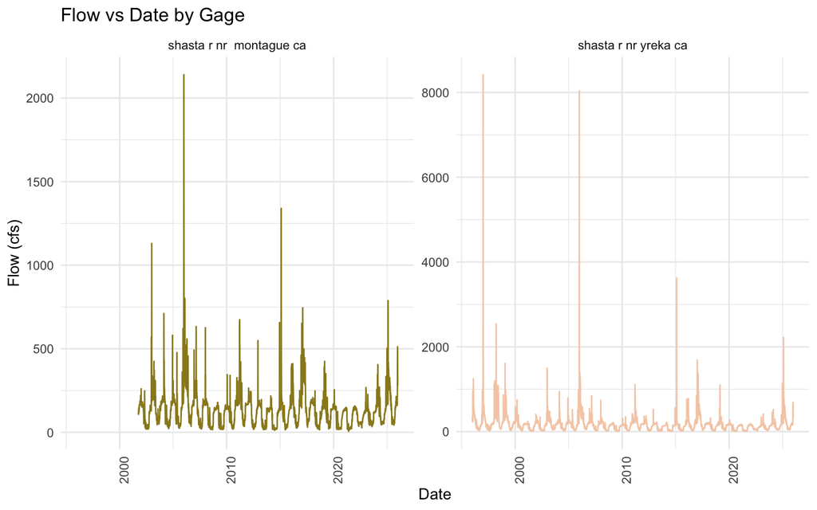

#### Date range summary

| gage_name | gage_id | min_date | max_date | record_count |
| --- | --- | --- | --- | --- |
| shasta r nr montague ca | 11517000 | 2001-10-01 | 2025-12-31 | 8858 |
| shasta r nr yreka ca | 11517500 | 1996-01-01 | 2025-12-31 | 10958 |

### Scott (HUC8 18010208)

#### Gages

| location | gage_name | gage_id | agency | river_mile |
| --- | --- | --- | --- | --- |
| mill creek | mill creek | QVIR-MICR | quartz valley indian community of the quartz valley reservation of california (tribal) | NA |
| scott river | scott river jones beach | QVIR-SRJB | quartz valley indian community of the quartz valley reservation of california (tribal) | 19 |
| scott river | townsends gulch | QVIR-SRTN | quartz valley indian community of the quartz valley reservation of california (tribal) | 11 |
| tompkins creek | tompkins creek | QVIR-TOMP | quartz valley indian community of the quartz valley reservation of california (tribal) | NA |
| middle creek | middle creek | QVIR-MIDC | quartz valley indian community of the quartz valley reservation of california (tribal) | NA |
| kelsey creek | kelsey creek | QVIR-KECR | quartz valley indian community of the quartz valley reservation of california (tribal) | NA |
| canyon creek | canyon creek | QVIR-CACR | quartz valley indian community of the quartz valley reservation of california (tribal) | NA |
| boulder creek | boulder creek | QVIR-BLCR | quartz valley indian community of the quartz valley reservation of california (tribal) | NA |
| duck lake creek | duck lake creek | NARS_WQX-WCAP99-0604 | epa national aquatic resources survey (nars) | NA |
| unnamed creek | unnamed creek | NARS_WQX-WCAP99-0583 | epa national aquatic resources survey (nars) | NA |
| sugar creek | sugar creek | NARS_WQX-WCAP99-1067 | epa national aquatic resources survey (nars) | NA |
| scott river | scott r nr fort jones ca | 11519500 | usgs | 22 |

#### Date coverage

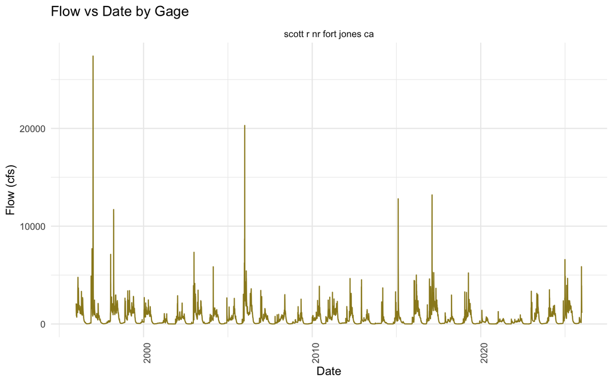

#### Date range summary

| gage_name | gage_id | min_date | max_date | record_count |
| --- | --- | --- | --- | --- |
| scott r nr fort jones ca | 11519500 | 1996-01-01 | 2025-12-31 | 10958 |

### Lower Klamath (HUC8 18010209)

#### Gages

| location | gage_name | gage_id | agency | river_mile |
| --- | --- | --- | --- | --- |
| indian creek | indian creek east fork | NARS_WQX-WCAP99-0613 | epa national aquatic resources survey (nars) | 8 |
| copper creek | copper creek | NARS_WQX-WCAP99-0811 | epa national aquatic resources survey (nars) | NA |
| buckhorn creek | buckhorn creek | NARS_WQX-WCAP99-0761 | epa national aquatic resources survey (nars) | NA |
| little pine creek | little pine creek | NARS_WQX-WCAP99-1005 | epa national aquatic resources survey (nars) | NA |
| west fork pecwan creek | west fork pecwan creek | NARS_WQX-WCAP99-1060 | epa national aquatic resources survey (nars) | NA |
| klamath river | klamath r a orleans | 11523000 | usgs | 59 |
| klamath river | klamath r nr klamath ca | 11530500 | usgs | 8 |
| indian creek | indian c nr happy camp ca | 11521500 | usgs | 4 |

#### Date coverage

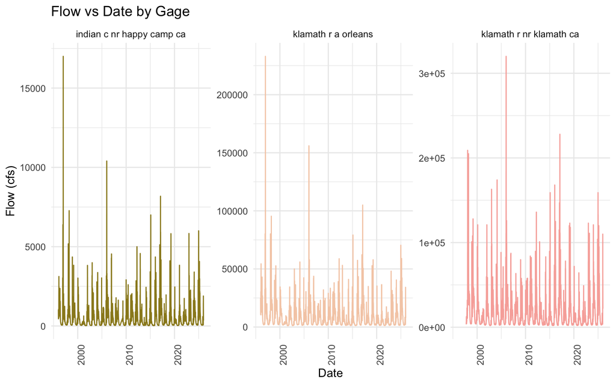

#### Date range summary

| gage_name | gage_id | min_date | max_date | record_count |
| --- | --- | --- | --- | --- |
| indian c nr happy camp ca | 11521500 | 1996-01-01 | 2025-12-31 | 10775 |
| klamath r a orleans | 11523000 | 1996-01-01 | 2025-12-31 | 10958 |
| klamath r nr klamath ca | 11530500 | 1997-10-01 | 2025-12-31 | 10319 |

### Salmon (HUC8 18010210)

#### Gages

| location | gage_name | gage_id | agency | river_mile |
| --- | --- | --- | --- | --- |
| scott river | scott river at gaging station | QVIR-SRGA | quartz valley indian community of the quartz valley reservation of california (tribal) | 49 |
| shackleford creek | shackleford creek at falls | QVIR-SHFL | quartz valley indian community of the quartz valley reservation of california (tribal) | NA |
| mcnel creek | mcnel creek | NARS_WQX-WCAP99-0598 | epa national aquatic resources survey (nars) | NA |
| south fork salmon river | south fork salmon river | NARS_WQX-WCAP99-1091 | epa national aquatic resources survey (nars) | NA |
| salmon river | salmon r a somes bar ca | 11522500 | usgs | 1 |

#### Date coverage

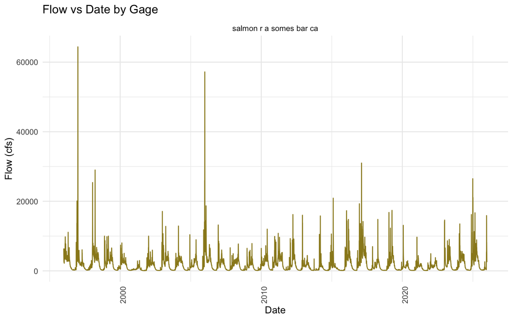

#### Date range summary

| gage_name | gage_id | min_date | max_date | record_count |
| --- | --- | --- | --- | --- |
| salmon r a somes bar ca | 11522500 | 1996-01-01 | 2025-12-31 | 10958 |

### Trinity (HUC8 18010211)

#### Gages

| location | gage_name | gage_id | agency | river_mile |
| --- | --- | --- | --- | --- |
| scott river | scott river south fork | QVIR-SRSF | quartz valley indian community of the quartz valley reservation of california (tribal) | 58 |
| shackleford creek | shackleford at reservation | QVIR-SRES | quartz valley indian community of the quartz valley reservation of california (tribal) | NA |
| stuart fork | stuart fork | NARS_WQX-WCAP99-0505 | epa national aquatic resources survey (nars) | NA |
| squirrel gulch | squirrel gulch | NARS_WQX-WCAP99-0574 | epa national aquatic resources survey (nars) | NA |
| mumbo creek | mumbo creek | NARS_WQX-WCAP99-0824 | epa national aquatic resources survey (nars) | NA |
| east fork coffee creek | east fork coffee creek | NARS_WQX-WCAP99-1079 | epa national aquatic resources survey (nars) | NA |
| reading creek | reading creek | NARS_WQX-WCAP99-1062 | epa national aquatic resources survey (nars) | NA |
| bear creek | bear creek | NARS_WQX-WCAP99-1055 | epa national aquatic resources survey (nars) | NA |
| big creek | big creek | NARS_WQX-WCAP99-0593 | epa national aquatic resources survey (nars) | NA |
| mill creek | mill creek | NARS_WQX-WCAP99-1066 | epa national aquatic resources survey (nars) | NA |
| browns creek | browns creek | NARS_WQX-WCAP99-0843 | epa national aquatic resources survey (nars) | NA |
| weaver creek | weaver creek | NARS_WQX-WCAP99-0812 | epa national aquatic resources survey (nars) | NA |
| browns creek | browns creek | NARS_WQX-WCAP99-0768 | epa national aquatic resources survey (nars) | NA |
| trinity river | trinity r a hoopa ca | 11530000 | usgs | 13 |
| trinity river | trinity r ab coffee c nr trinity center ca | 11523200 | usgs | 147 |
| trinity river | trinity r a lewiston ca | 11525500 | usgs | 113 |
| trinity river | trinity r bl limekiln gulch nr douglas city ca | 11525655 | usgs | 100 |
| trinity river | trinity r a douglas city ca | 11525854 | usgs | 94 |
| trinity river | trinity r a junction city ca | 11526250 | usgs | 81 |
| trinity river | trinity r ab nf trinity r nr helena ca | 11526400 | usgs | 74 |
| trinity river | trinity r nr burnt ranch ca | 11527000 | usgs | 49 |
| indian creek | indian c nr douglas city ca | 11525670 | usgs | 0 |

#### Date coverage

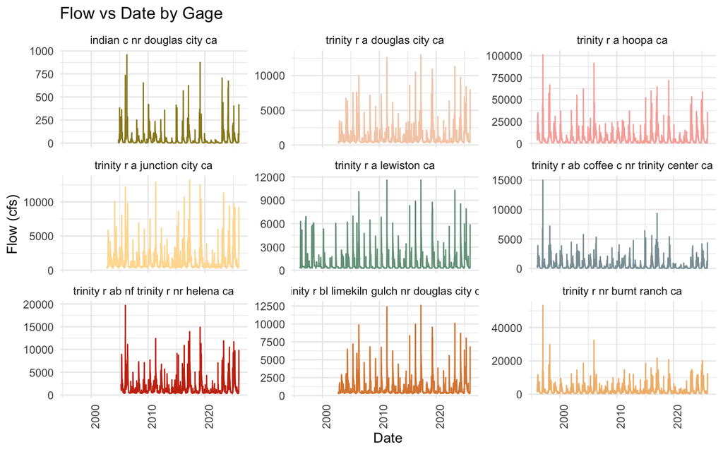

#### Date range summary

| gage_name | gage_id | min_date | max_date | record_count |
| --- | --- | --- | --- | --- |
| indian c nr douglas city ca | 11525670 | 2004-10-01 | 2025-12-31 | 7762 |
| trinity r a douglas city ca | 11525854 | 2002-10-01 | 2025-12-31 | 8493 |
| trinity r a hoopa ca | 11530000 | 1996-01-01 | 2025-12-31 | 10958 |
| trinity r a junction city ca | 11526250 | 2002-10-01 | 2025-12-31 | 8493 |
| trinity r a lewiston ca | 11525500 | 1996-01-01 | 2025-12-31 | 10958 |
| trinity r ab coffee c nr trinity center ca | 11523200 | 1996-01-01 | 2025-12-31 | 10958 |
| trinity r ab nf trinity r nr helena ca | 11526400 | 2005-03-29 | 2025-12-31 | 7583 |
| trinity r bl limekiln gulch nr douglas city ca | 11525655 | 2002-10-01 | 2025-12-31 | 8493 |
| trinity r nr burnt ranch ca | 11527000 | 1996-01-01 | 2025-12-31 | 10958 |

### South Fork Trinity (HUC8 18010212)

#### Gages

| location | gage_name | gage_id | agency | river_mile |
| --- | --- | --- | --- | --- |
| grassy flat creek | grassy flat creek | NARS_WQX-WCAP99-0587 | epa national aquatic resources survey (nars) | NA |
| prospect creek | prospect creek | NARS_WQX-WCAP99-0581 | epa national aquatic resources survey (nars) | NA |
| corral creek | corral creek | NARS_WQX-WCAP99-0831 | epa national aquatic resources survey (nars) | NA |
| sf trinity river | sf trinity r bl hyampom ca | 11528700 | usgs | NA |

#### Date coverage

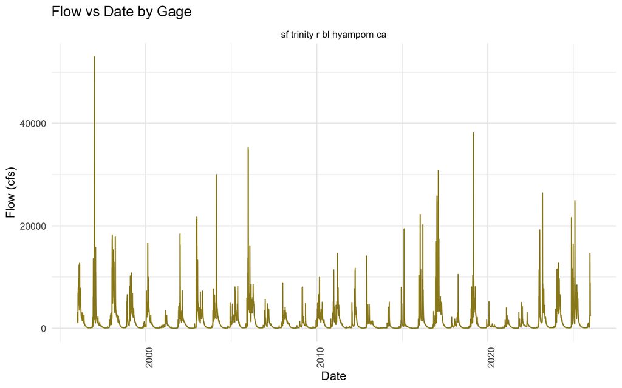

#### Date range summary

| gage_name | gage_id | min_date | max_date | record_count |
| --- | --- | --- | --- | --- |
| sf trinity r bl hyampom ca | 11528700 | 1996-01-01 | 2025-12-31 | 10958 |